# APS1070

#### Project 1 --- Basic Principles and Models

**Deadline: Oct 6th, 11PM - 10 percent**

**Academic Integrity**

This project is individual - it is to be completed on your own. If you have questions, please post your query in the APS1070 Piazza Q&A forums (the answer might be useful to others!).

Do not share your code with others, or post your work online. Do not submit code that you have not written yourself. Students suspected of plagiarism on a project, midterm or exam will be referred to the department for formal discipline for breaches of the Student Code of Conduct.

Name: Declan Bracken *(here and elsewhere, please replace the underscore with your answer)*

Student ID: 1006251324

## **Marking Scheme:**

This project is worth **10 percent** of your final grade.

Draw a plot or table where necessary to summarize your findings.

**Practice Vectorized coding**: If you need to write a loop in your solution, think about how you can implement the same functionality with vectorized operations. Try to avoid loops as much as possible (in some cases, loops are inevitable).

### How to submit **(HTML + IPYNB)**

1. Download your notebook: `File -> Download .ipynb`
2. Click on the Files icon on the far left menu of Colab
3. Select & upload your `.ipynb` file you just downloaded, and then obtain its path (right click) (you might need to hit the Refresh button before your file shows up)
1. execute the following in a Colab cell:

   ```
   %%shell
   jupyter nbconvert --to html /PATH/TO/YOUR/NOTEBOOKFILE.ipynb
   ```

2. An HTML version of your notebook will appear in the files, so you can download it.
3. Submit **both** `HTML` and `IPYNB` files on Quercus for grading.

Ref: https://stackoverflow.com/a/64487858

# Project 1 [10 Marks]

Let's apply the tools we have learned in the tutorial to a new dataset.

We're going to work with a [boston dataset](https://openml.org/search?type=data&status=any&id=43465). Download it using the cell below:

```python
from sklearn.datasets import fetch_openml
import numpy as np
import matplotlib.pyplot as plt
dataset = fetch_openml(name='Boston-house-price-data', version=1, parser="auto")
```

## Part 1: Getting started [2.5 Marks]

First off, take a look at the `data`, `target` and `feature_names` entries in the `dataset` dictionary. They contain the information we'll be working with here. Then, create a Pandas DataFrame called `df` containing the data and the targets, with the feature names as column headings. If you need help, see [here](https://pandas.pydata.org/pandas-docs/stable/reference/api/pandas.DataFrame.html) for more details on how to achieve this. **[0.4]**

- How many features do we have in this dataset? 13
- Determine the median target value. 21.2
- How many participants have a target value greater than the median target value? 250

Now add an additional column containing either 0 (if the target value is below the median) or 1 (if the target value is above the median). This will be the new target value to classify the data as the owner-occupied homes value in \$1000's below median or the owner-occupied homes value in \$1000's above median. **[0.5]**

```python
import pandas as pd
df = pd.DataFrame(dataset['data'],columns = dataset['feature_names']) #turn into datafram
df['target'] = dataset['target'] #add target column

df_median = df.target.median() #get median
greater_than_median_target = df.target.loc[df.target > df_median].size #number of samples above the median
df['Class'] = (df.target>df_median).astype(int) #make column for new target value "Class"
print("Median target is ",df_median)
df.head() #check
```

[output not shown]

|  | CRIM | ZN | INDUS | CHAS | NOX | RM | AGE | DIS | RAD | TAX | PTRATIO | B | LSTAT | target | Class |
| --- | --- | --- | --- | --- | --- | --- | --- | --- | --- | --- | --- | --- | --- | --- | --- |
| 0 | 0.00632 | 18.0 | 2.31 | 0.0 | 0.538 | 6.575 | 65.2 | 4.0900 | 1.0 | 296.0 | 15.3 | 396.90 | 4.98 | 24.0 | 1 |
| 1 | 0.02731 | 0.0 | 7.07 | 0.0 | 0.469 | 6.421 | 78.9 | 4.9671 | 2.0 | 242.0 | 17.8 | 396.90 | 9.14 | 21.6 | 1 |
| 2 | 0.02729 | 0.0 | 7.07 | 0.0 | 0.469 | 7.185 | 61.1 | 4.9671 | 2.0 | 242.0 | 17.8 | 392.83 | 4.03 | 34.7 | 1 |
| 3 | 0.03237 | 0.0 | 2.18 | 0.0 | 0.458 | 6.998 | 45.8 | 6.0622 | 3.0 | 222.0 | 18.7 | 394.63 | 2.94 | 33.4 | 1 |
| 4 | 0.06905 | 0.0 | 2.18 | 0.0 | 0.458 | 7.147 | 54.2 | 6.0622 | 3.0 | 222.0 | 18.7 | 396.90 | 5.33 | 36.2 | 1 |

### Splitting the data

It is best practice to have a training set (from which there is a rotating validation subset) and a test set. Our aim here is to (eventually) obtain the best accuracy we can on the test set (we'll do all our tuning on the training/validation sets, however.)

**Split the dataset** into a train and a test set **"70:30"**, use **`random_state=0`**. The test set is set aside (untouched) for final evaluation, once hyperparameter optimization is complete. **[0.5]**

**Only Split the dataset once within you notebook.** You should not use the `train_test_split` function more than once, regardless of the random state. Keep this in mind for your future projects as well.

```python
### YOUR CODE HERE ###

from sklearn.model_selection import train_test_split #import necessary function

#take only data that is not target or class for training, then take only class for testing
X_train, X_test, y_train, y_test = train_test_split(df.iloc[:,:-2],df.iloc[:,-1], test_size = 0.3, random_state = 0) #split data
X_train.head()
```

|  | CRIM | ZN | INDUS | CHAS | NOX | RM | AGE | DIS | RAD | TAX | PTRATIO | B | LSTAT |
| --- | --- | --- | --- | --- | --- | --- | --- | --- | --- | --- | --- | --- | --- |
| 141 | 1.62864 | 0.0 | 21.89 | 0.0 | 0.624 | 5.019 | 100.0 | 1.4394 | 4.0 | 437.0 | 21.2 | 396.90 | 34.41 |
| 272 | 0.11460 | 20.0 | 6.96 | 0.0 | 0.464 | 6.538 | 58.7 | 3.9175 | 3.0 | 223.0 | 18.6 | 394.96 | 7.73 |
| 135 | 0.55778 | 0.0 | 21.89 | 0.0 | 0.624 | 6.335 | 98.2 | 2.1107 | 4.0 | 437.0 | 21.2 | 394.67 | 16.96 |
| 298 | 0.06466 | 70.0 | 2.24 | 0.0 | 0.400 | 6.345 | 20.1 | 7.8278 | 5.0 | 358.0 | 14.8 | 368.24 | 4.97 |
| 122 | 0.09299 | 0.0 | 25.65 | 0.0 | 0.581 | 5.961 | 92.9 | 2.0869 | 2.0 | 188.0 | 19.1 | 378.09 | 17.93 |

### Effect of Standardization (Visual)

Use `seaborn.lmplot` ([help here](https://seaborn.pydata.org/generated/seaborn.lmplot.html)) to visualize a few features of the training set. Draw a plot where the x-axis is the *proportion of owner-occupied units built prior to 1940* i.e. `AGE`, the y-axis is the *weighted distances to five Boston employment centres* i.e. `DIS`, and the color of each datapoint indicates its class. **[0.5]**

Standardizing the data is often critical in machine learning. Show a plot as above, but standardize the two features. What's different? **why do they look similar?** Based on your observation, what is the advantage of standardization? **[0.6]**

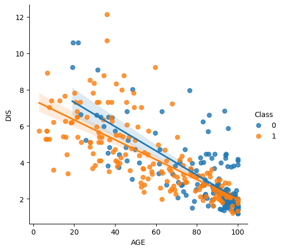

```python
### YOUR CODE HERE ###

import seaborn as sns

merged_training_set = X_train.copy() #create copy to reincorporate class
merged_training_set['Class'] = y_train
sns.lmplot(data=merged_training_set, x="AGE", y="DIS", hue="Class")
```

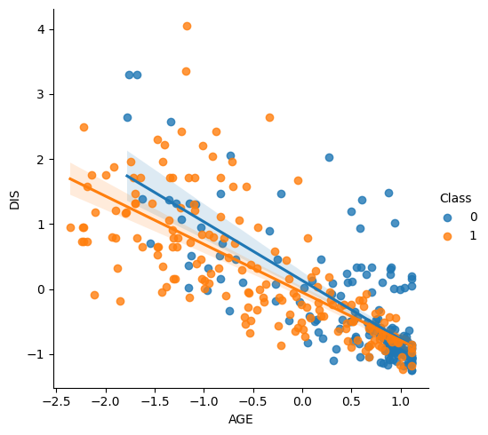

```python
X_train_standard = (X_train - X_train.mean()) / X_train.std()
merged_training_set2 = X_train_standard #create copy to reincorporate class
merged_training_set2['Class'] = y_train
sns.lmplot(data=merged_training_set2, x="AGE", y="DIS", hue='Class')
```

**Standardization**:

The only observable difference between the 2 plots is the perspective scale of their axis. After standardization, both the x and the y axis of either binary class has been proportionaly scaled, meaning no difference will be observed in the relationship between the 2 classes, only between their absolute values. The advantage of standardization comes into play with data that have variable units of measurement or with a very large range of values. Through standardization, data is formated so that numeric values are close together, and all units are the same, while maintaining the proportionality of the data set.

## Part 2: KNN Classifier without Standardization [2 Marks]

Normally, standardizing data is a key step in preparing data for a KNN classifier. However, for educational purposes, let's first try to build a model without standardization. Let's create a KNN classifier to predict whether a house has the owner-occupied homes value that is less than the median or greater than the median.

Follow these steps:

1. Train a KNN Classifier using cross-validation on the dataset. Sweep `k` (number of neighbours) from 1 to 100, and show a plot of the mean cross-validation accuracy vs `k`. **[1]**
2. What is the best `k`? What is the highest cross-validation accuracy? **[0.5]**
3. Comment on which ranges of `k` lead to underfitted or overfitted models (hint: compare training and validation curves!). **[0.5]**

```
The model performed best with a k of 3, achieving an accuracy of 0.8051509054325955
```

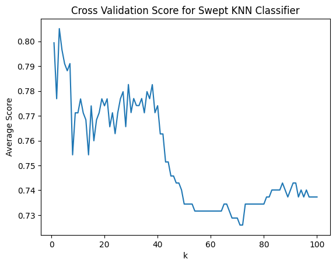

```python
### YOUR CODE HERE ###

from sklearn.neighbors import KNeighborsClassifier
from sklearn.model_selection import cross_val_score
import numpy as np
from matplotlib import pyplot as plt

"""
  args:
    X_train: X training data set in the form of a data frame
    y_train: ground truth data
    k_max: maximum k to sweep upto (starting at 1 and increasing by 1 per iteration)
    num_folds: automatically set to 5, the number of folds set for cross validation
    plot: boolean. If True, a plot of the mean cross validation score over the k-range swept will be shown.

  output:
    highest_accuracy: The highest accuracy achieved by the classifier
    k_best: The k value used to achieve the highest accuracy
"""

def train_knn(X_train, y_train, k_max, num_folds = 5, plot = False):

  #k-values to sweep
  k_values = np.arange(1,k_max+1)
  avg_scores = np.zeros(k_values.size)

  for i in range(len(k_values)):
    #create classifier
    knn_classifier = KNeighborsClassifier(n_neighbors=k_values[i])
    #get cross-val score
    scores = cross_val_score(knn_classifier, X_train, y_train, cv=num_folds)
    # Calculate the average score across all folds
    avg_scores[i] = np.mean(scores)

  # Find highest score and corresponding k value:
  highest_accuracy = np.max(avg_scores)
  k_best = k_values[np.argmax(avg_scores)]

  #Optional Plotting
  if plot:
    plt.plot(k_values,avg_scores)
    plt.xlabel("k")
    plt.ylabel("Average Score")
    plt.title("Cross Validation Score for Swept KNN Classifier")

  return highest_accuracy, k_best

highest_acc, k_best = train_knn(X_train, y_train, k_max = 100, num_folds = 5, plot = True)

print("The model performed best with a k of {}, achieving an accuracy of {}".format(k_best,highest_acc))
```

1. The 'best' k, categorized as the value of k which yielded the maximum cross-validation score was k = 3 with a CV score of 0.805, or 80.5% accuracy.
2. I would catergorize overfitting as any k value lower than k = 3. k = 1 or 2 will tend to overparameterize the classification of the data. The range of values between k = 8 to 40 result in a roughly similar accuracy range between 75% and 79% accuracy. These values are underfit, but not as underfit as the steep dropoff visible after k=40, with a very clear pattern of underfitting demonstrating accuracy scores in the range of 73 - 74%.

## Part 3: Feature Selection [3 Marks]

In this part, we aim to investigate the importance of each feature on the final classification accuracy. If we want to try every possible combination of features, we would have to test $2^F$ different cases, where F is the number of features, and in each case, we have to do a hyperparameter search (finding K, in KNN using cross-validation). That will take days!.

To find more important features we will use a decision tree. based on a decision tree we can compute feature importance that is a metric for our feature selection (code is provided below).

You can use [this link](https://machinelearningmastery.com/calculate-feature-importance-with-python/) to get familiar with extracting the feature impotance order of machine learning algorithms in Python.

After we identified and removed the least important feature and evaluated a new KNN model on the new set of features, if the stop conditions (see step 7 below) are not met, we need to repeat the process and remove another feature.

Design a function ( `Feature_selector`) that accepts your dataset (X_train , y_train) and a threshold as inputs and: **[1]**

1. Fits a decision tree classifier on the training set.
2. Extracts the feature importance order of the decision tree model.
3. Removes the least important feature based on step 2.
4. Then, a KNN model is trained on the remaining features. The number of neighbors (`k`) for each KNN model should be tuned using a 5-fold cross-validation.
5. Store the best `mean cross-validation` score and the corresponding `k` (number of neighbours) value in two lists.
6. Go back to step 3 and follow all the steps until you meet the stop condition (step 7).
7. We will stop this process when (1) there is only one feature left, or (2) our cross-validation accuracy is dropped significantly compared to a model that uses all the features. In this function, we accept a threshold as an input argument. For example, if threshold=0.95 we do not continue removing features if our mean cross-validation accuracy after tuning `k` is bellow **0.95 $\times$ Full Feature cross-validation accuracy**.
8. Your function returns the list of removed features, and the corresponding mean cross-validation accuracy and `k` value when a feature was removed.
- Visualize your results by plotting the mean cross-validation accuracy (with a tuned `k` on y axis) vs. the on the number of features (x axis). This plot describes: what is the best cv score with 1 feature, 2 features, 3 features ... and all the features. **[0.5]**
- Plot the best value of `k` (y-axis) vs. the number of features. This plot explains the trend of number of neighbours with respect to the number of features. **[0.5]**
- State what is the number of essential features for classification and justify your answer. **[1]**

The highest cross validation accuracy comes with only 2 features used for KNN classification, so I would say the best features for classification are LSTAT and RM (2 features). That said, LSTAT has by far the highest importance at 0.59, so even with only one feature, the classification accuracy is 0.847 or 84%. Given that this is only ~4% lower than with the optimum number of features, and ~4% higher than classification using ALL features, I would say the minimum number of features for classification is 1. That said this answer is entirely dependant on what you would deem an 'essential' feature. If essential means the number of features for optimum performance, than 2 features is the answer. If essential just means the number of features which contribute to the vast majority of successful classification, than 1: LSTAT.

You can use the following piece of code to start training a decision tree classifier and obtain its feature importance order.

```
from sklearn import tree
dt = tree.DecisionTreeClassifier()
dt.fit(X_train,y_train)
importance = dt.feature_importances_
```

```python
# import modules

from sklearn.tree import DecisionTreeRegressor

def Feature_selector (X_train , y_train , tr=0.95):
### YOUR CODE HERE ###

  # Initialize lists to keep stuff
  removed_features = []
  CVS_post_feature_removal = []
  k_best_post_feature_removal = []

  # new variable for continuity purposes
  X_train_dropped = X_train.copy()

  # Get list of features
  features = np.array(X_train_dropped.columns)

  # 1. Fit Decision Tree Classifier
  # choose random_state = 0 for consistency of classifier, otherwise results change.
  decision_tree_model = DecisionTreeRegressor(random_state = 0)
  decision_tree_model.fit(X_train_dropped, y_train)

  # 2. Extract the feature importance order of the decision tree model
  importance = decision_tree_model.feature_importances_

  #sort features by importance:
  features_sorted = [x for _,x in sorted(zip(importance,features))]
  importance.sort() # (purely for printing purposes)

  for i in range(len(features_sorted)):
    print("Feature {} has importance {}".format(features_sorted[i],importance[i]))

  # Begin looping until stop condition is met
  for feature in features_sorted:

    # 3. Remove least important feature
    X_train_dropped = X_train_dropped.drop(feature,axis = 1)
    print("Removed {}".format(feature))
    removed_features.append(feature)

    # 4. Train KNN on remaining features. Optimize using cross val by sweeping k
    # Sweep upto a k of 50 with 5 folds.
    CV_score, best_k = train_knn(X_train_dropped, y_train, k_max = 50, num_folds = 5, plot = False)

    # 5. Store the best mean cross-validation score and the corresponding k value in two lists
    CVS_post_feature_removal.append(CV_score)
    k_best_post_feature_removal.append(best_k)

    # 6. Repeat until stop condition is met (1 feature left or CV score is 0.95 after sweeping k)
    if (X_train_dropped.shape[1] == 1) or (CV_score > tr):
      break

    # 7. Return list of removed features, mean cross val score, and k value when a feature was removed.
  return removed_features, CVS_post_feature_removal, k_best_post_feature_removal

removed_features, CVS_post_feature_removal, k_best_post_feature_removal = Feature_selector(X_train, y_train)
print("Best Cross Validation Score is {}".format(np.max(CVS_post_feature_removal)))
```

```
Feature CHAS has importance 0.0
Feature RAD has importance 0.0
Feature INDUS has importance 0.010798976257192549
Feature NOX has importance 0.01291405223989494
Feature ZN has importance 0.013559754851889686
Feature TAX has importance 0.017249042285365435
Feature B has importance 0.03195331120190671
Feature CRIM has importance 0.03633386741904303
Feature PTRATIO has importance 0.0440712188289129
Feature AGE has importance 0.06956640175278132
Feature DIS has importance 0.08625605841355333
Feature RM has importance 0.08693964637705569
Feature LSTAT has importance 0.5903576703724045
Removed CHAS
Removed RAD
Removed INDUS
Removed NOX
Removed ZN
Removed TAX
Removed B
Removed CRIM
Removed PTRATIO
Removed AGE
Removed DIS
Removed RM
Best Cross Validation Score is 0.8841046277665996
```

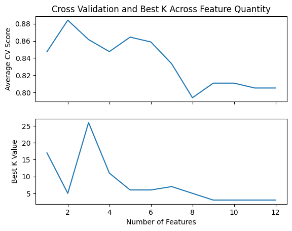

```python
feature_quantity = X_train.shape[1]-np.arange(1,len(removed_features)+1)
fig, axs = plt.subplots(2,1, sharex = True)
axs[0].set_title("Cross Validation and Best K Across Feature Quantity")
axs[0].plot(feature_quantity,CVS_post_feature_removal)
axs[0].set_ylabel("Average CV Score")
axs[1].plot(feature_quantity,k_best_post_feature_removal)
axs[1].set_xlabel("Number of Features")
axs[1].set_ylabel("Best K Value")
```

## Part 4: Standardization [1 Marks]

Standardizing the data usually means scaling our data to have a mean of zero and a standard deviation of one.

**Note:** When we standardize a dataset, do we care if the data points are in our training set or test set? Yes! The training set is available for us to train a model - we can use it however we want. The test set, however, represents a subset of data that is not available for us during training. For example, the test set can represent the data that someone who bought our model would use to see how the model performs (which they are not willing to share with us). Therefore, we cannot compute the mean or standard deviation of the whole dataset to standardize it - we can only calculate the mean and standard deviation of the training set. However, when we sell a model to someone, we can say what our scalers (mean and standard deviation of our training set) was. They can scale their data (test set) with our training set's mean and standard deviation. Of course, there is no guarantee that the test set would have a mean of zero and a standard deviation of one, but it should work fine.

**To summarize: We fit the StandardScaler only on the training set. We transform both training and test sets with that scaler.**

1. Standardize the training and test data ([Help](https://scikit-learn.org/stable/modules/preprocessing.html))
2. Call your `Feature_selector` function on the standardized training data with a threshold of 95\%.
   - Plot the Cross validation accuracy when we have the standardized data (this part) and the original training data (last part) vs. the Number of features in a single plot (to compare them easily).
3. Discuss how standardization affected your model and its performance?

```python
### YOUR CODE HERE ###

# 1. Standardize Data
mean = X_train.mean() #get training avg
std = X_train.std() #get training standard deviation

# Adjust training and test data according to training stats
X_train_standard = (X_train - mean) / std
X_test_standard = (X_test - mean) / std

# 2. Call Feature Selector
removed_features, CVS_post_feature_removal_standard, k_best_standard = Feature_selector(X_train_standard, y_train)
print("Best Cross Validation Score is {}".format(np.max(CVS_post_feature_removal_standard)))
```

```
Feature CHAS has importance 0.0
Feature RAD has importance 0.0
Feature INDUS has importance 0.010798976257192549
Feature NOX has importance 0.01291405223989494
Feature ZN has importance 0.013559754851889686
Feature TAX has importance 0.017249042285365435
Feature B has importance 0.03195331120190671
Feature CRIM has importance 0.03633386741904303
Feature PTRATIO has importance 0.0440712188289129
Feature AGE has importance 0.06956640175278132
Feature DIS has importance 0.08625605841355333
Feature RM has importance 0.08693964637705569
Feature LSTAT has importance 0.5903576703724045
Removed CHAS
Removed RAD
Removed INDUS
Removed NOX
Removed ZN
Removed TAX
Removed B
Removed CRIM
Removed PTRATIO
Removed AGE
Removed DIS
Removed RM
Best Cross Validation Score is 0.8785915492957747
```

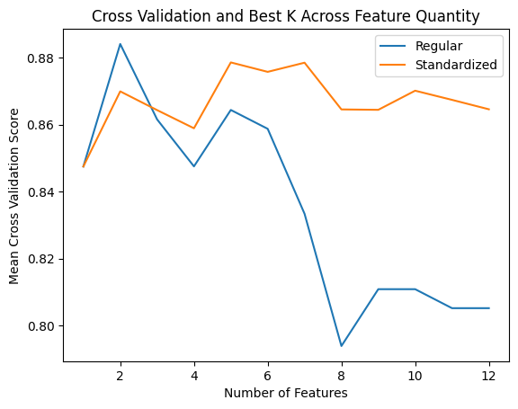

```python
# Plot
feature_quantity = X_train_standard.shape[1]-np.arange(1,len(removed_features)+1)

fig, axs = plt.subplots(1,1)

axs.set_title("Cross Validation and Best K Across Feature Quantity")
axs.plot(feature_quantity,CVS_post_feature_removal, label = "Regular")
axs.plot(feature_quantity,CVS_post_feature_removal_standard, label = "Standardized")
axs.set_xlabel("Number of Features")
axs.set_ylabel("Mean Cross Validation Score")
plt.legend()
```

```python
"""
Standardization did not improve the highest mean cross validation accuracy.
That said, the entire cross-validation accuracy for any given number of
features fed into the classifier increased across the board (with the exception
of the 2 feature case). This is especially true at the higher end where using 12
features in the standardized data set increases cross validation accuracy from
~80% to ~86%. Overall, standardization allowed the inclusion of more data, which
leads to improves results for many different feature numbers.

Note: Before I began using a fixed random state for the classifier, I actually
did manage to get the standardized data with 8 features to have a higher
CVS at 88.7% vs the previous 88.4%, but I couldn't replicate this result due
to the undefined random state. So just saying, it is possible within this dataset
for standardization to improve the result while using 8 features, it just
required some luck.
"""
```

[output not shown]